# Recommended-size classifier: v0

In the previous notebook we proved that predicting a font's `opsz` value *as a number* doesn't generalise across families — every designer encodes their own opsz scale differently.

But the actual ask is coarser: *"Tell me Lobster is for 24pt and above."* That's a **bucketed classification** problem, not a regression one. Buckets absorb the cross-family variance: everyone agrees that Lobster is a Display font, even if they'd disagree on whether it's a 60pt or 72pt design.

This notebook walks through the v0 classifier and shows it working on real fonts.

## The buckets

Five ordinal labels, each tied to a minimum recommended size:

| Bucket | Min size | What lives there |
| --- | --- | --- |
| Caption | 5–9pt | Designed for very small body, larger x-height, low contrast |
| Text | 9–14pt | Standard body — Inter, Roboto, Source Sans, most serifs |
| Subhead | 14–24pt | Tighter or sharper than body — Oswald, Cormorant, Slabo27px |
| Display | 24–48pt | Headline-only serifs / sans — Playfair Display, Abril Fatface |
| Display+ | 48pt+ | Decorative, extreme, or single-purpose — Lobster, Bungee, Anton |

## Training data

Two sources, mixed together:

```python
import pandas as pd
import numpy as np
import matplotlib.pyplot as plt
import seaborn as sns
from pathlib import Path

sns.set_style("whitegrid")
plt.rcParams["figure.dpi"] = 100

ROOT = Path.home() / "Type/opsz_research"

df_vf = pd.read_csv(ROOT / "measurements.csv").assign(source="opsz_vf")
df_static = pd.read_csv(ROOT / "classifier/measurements_static.csv").assign(source="static")
df = pd.concat([df_vf, df_static], ignore_index=True)

BUCKETS = ["Caption", "Text", "Subhead", "Display", "Display+"]
BOUNDS = [(5, 9), (9, 14), (14, 24), (24, 48), (48, 300)]

def bucket(o):
    for i, (lo, hi) in enumerate(BOUNDS):
        if lo <= o < hi:
            return i
    return 4

df["bucket"] = df["axis_opsz"].apply(bucket)
df["bucket_name"] = df["bucket"].apply(lambda i: BUCKETS[i])

print(f"Training rows: {len(df)}  ({(df['source']=='opsz_vf').sum()} from opsz VFs, {(df['source']=='static').sum()} hand-labelled)")
df.groupby(["bucket_name", "source"]).size().unstack(fill_value=0).reindex(BUCKETS)
```

```
Training rows: 373  (308 from opsz VFs, 65 hand-labelled)
```

| source bucket_name | opsz_vf | static |
| --- | --- | --- |
| Caption | 26 | 1 |
| Text | 30 | 38 |
| Subhead | 54 | 8 |
| Display | 72 | 6 |
| Display+ | 126 | 12 |

Class distribution leans heavily Display+ (because opsz VFs sample uniformly over a range that often reaches 144pt, and lots of those samples land in Display+). The hand-labels rebalance the Text bucket a bit. Caption is still thin — only one true caption-only static face exists in Google Fonts (Slabo13px).

Quick look at the feature space: every training point projected into two of the strong signals (stem-to-x-height ratio vs stroke contrast ratio), coloured by bucket.

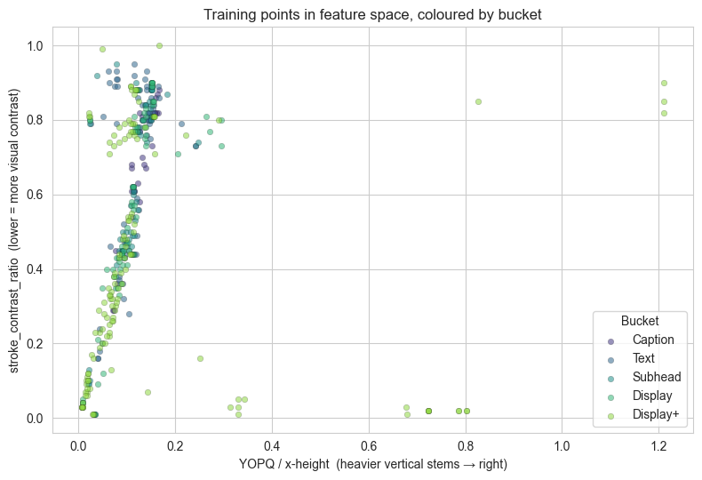

```python
d = df.copy()
d["stem_to_xh"] = d["YOPQ"] / d["x_height"]
d = d.dropna(subset=["stem_to_xh", "stroke_contrast_ratio"]).reset_index(drop=True)

fig, ax = plt.subplots(figsize=(8, 5.5))
palette = sns.color_palette("viridis", n_colors=len(BUCKETS))
for i, name in enumerate(BUCKETS):
    sub = d[d["bucket"] == i]
    ax.scatter(sub["stem_to_xh"], sub["stroke_contrast_ratio"],
               alpha=0.55, s=22, color=palette[i], label=name,
               edgecolors="black", linewidths=0.2)
ax.set_xlabel("YOPQ / x-height  (heavier vertical stems → right)")
ax.set_ylabel("stroke_contrast_ratio  (lower = more visual contrast)")
ax.set_title("Training points in feature space, coloured by bucket")
ax.legend(title="Bucket")
plt.tight_layout()
plt.show()
```

The clusters overlap significantly — there's no clean two-feature split between buckets. The model has to do its work in higher-dimensional space (we feed it eight features), where the boundaries are sharper. The takeaway: humans can read this chart and see a rough trend (Display+ skews to the upper-right, Text/Subhead live in the middle), but no single feature is the answer.

## The model

A 5-class Random Forest on eight features:

- `YOPQ / x-height` — vertical stem weight, normalised
- `XOPQ / x-height` — horizontal stem weight, normalised
- `x-height / cap-height` — proportion
- `XTRA / x-height` — counter width, normalised
- `stroke_contrast_ratio` — thin/thick (low = more contrast)
- `stroke_contrast_angle` — direction of contrast
- `weight`, `width` — fontquant's overall ink/density measures

We evaluate with **leave-one-family-out cross-validation** — the realistic test, because at deploy time the model will see fonts from families it never trained on.

```
Exact accuracy:      39%
Off-by-one accuracy: 69%  (predicting Subhead when truth is Display, etc.)
Baseline (majority class): 37%
```

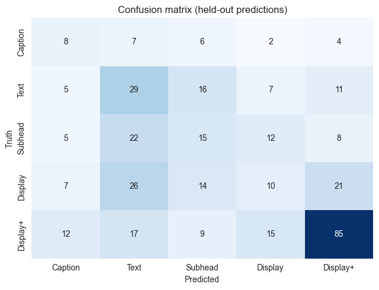

```python
from sklearn.ensemble import RandomForestClassifier
from sklearn.metrics import confusion_matrix
from sklearn.model_selection import LeaveOneGroupOut
from sklearn.preprocessing import StandardScaler

FEATURES = ["stem_to_xh", "hstem_to_xh", "xh_to_cap", "xtra_to_xh",
            "stroke_contrast_ratio", "stroke_contrast_angle", "weight", "width"]

d["hstem_to_xh"] = d["XOPQ"] / d["x_height"]
d["xh_to_cap"]   = d["x_height"] / d["cap_height"]
d["xtra_to_xh"]  = d["XTRA"] / d["x_height"]
d = d.dropna(subset=FEATURES).reset_index(drop=True)
X, y, g = d[FEATURES].values, d["bucket"].values, d["family_dir"].values

preds = np.empty_like(y)
for tr, te in LeaveOneGroupOut().split(X, y, g):
    scaler = StandardScaler().fit(X[tr])
    m = RandomForestClassifier(n_estimators=400, max_depth=6,
                                class_weight="balanced", random_state=0)
    m.fit(scaler.transform(X[tr]), y[tr])
    preds[te] = m.predict(scaler.transform(X[te]))

exact = (preds == y).mean()
off_by_one = (np.abs(preds - y) <= 1).mean()
print(f"Exact accuracy:      {exact:.0%}")
print(f"Off-by-one accuracy: {off_by_one:.0%}  (predicting Subhead when truth is Display, etc.)")
print(f"Baseline (majority class): {pd.Series(y).value_counts(normalize=True).max():.0%}")

cm = confusion_matrix(y, preds)
fig, ax = plt.subplots(figsize=(6.5, 5))
sns.heatmap(cm, annot=True, fmt="d", cmap="Blues", cbar=False,
            xticklabels=BUCKETS, yticklabels=BUCKETS, ax=ax)
ax.set_xlabel("Predicted"); ax.set_ylabel("Truth")
ax.set_title("Confusion matrix (held-out predictions)")
plt.tight_layout(); plt.show()
```

Now the actual demo.

## Live demo

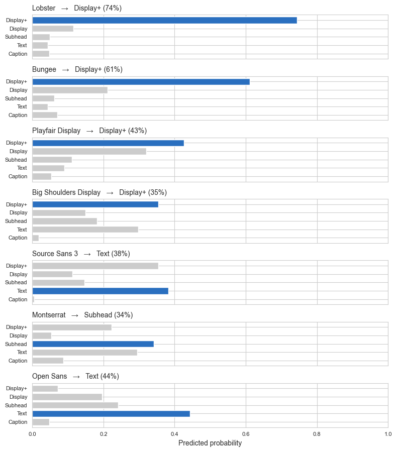

```python
import joblib
from fontquant import quantify

PKG = joblib.load(ROOT / "classifier/model.joblib")
model, scaler, features = PKG["model"], PKG["scaler"], PKG["features"]

OFL = Path.home() / "Type/fonts/ofl"
DEMO = [
    ("Lobster",          OFL / "lobster/Lobster-Regular.ttf"),
    ("Bungee",           OFL / "bungee/Bungee-Regular.ttf"),
    ("Playfair Display", OFL / "playfairdisplay/PlayfairDisplay[wght].ttf"),
    ("Big Shoulders Display", OFL / "bigshouldersdisplay/BigShouldersDisplay[wght].ttf"),
    ("Source Sans 3",    OFL / "sourcesans3/SourceSans3[wght].ttf"),
    ("Montserrat",       OFL / "montserrat/Montserrat[wght].ttf"),
    ("Open Sans",        OFL / "opensans/OpenSans[wdth,wght].ttf"),
]

def features_for(path):
    res = quantify(str(path), includes=["appearance"], locations=None)
    m = {k: v.get("value") for k, v in res.get("appearance", {}).items()}
    return [m["YOPQ"]/m["x_height"], m["XOPQ"]/m["x_height"],
            m["x_height"]/m["cap_height"], m["XTRA"]/m["x_height"],
            m["stroke_contrast_ratio"], m["stroke_contrast_angle"],
            m["weight"], m["width"]]

results = []
for name, path in DEMO:
    probs = model.predict_proba(scaler.transform([features_for(path)]))[0]
    results.append((name, probs))

fig, axes = plt.subplots(len(results), 1, figsize=(8, 1.3 * len(results)), sharex=True)
for ax, (name, probs) in zip(axes, results):
    top = int(np.argmax(probs))
    colors = ["#cccccc"] * len(BUCKETS)
    colors[top] = "#2a6fbf"
    ax.barh(BUCKETS, probs, color=colors)
    ax.set_title(f"{name}   →   {BUCKETS[top]} ({probs[top]:.0%})", loc="left", fontsize=10)
    ax.set_xlim(0, 1)
    ax.tick_params(labelsize=8)
axes[-1].set_xlabel("Predicted probability")
plt.tight_layout()
plt.show()
```

## Read of the demo

- **Lobster** — Display+ at 74%. The flagship example, classified confidently.
- **Bungee** — Display+ at 61%. The original opsz-VF-only model called this Caption (wildly wrong) because Bungee's measurements are out-of-distribution relative to conventional opsz VFs; the hand-labels fixed it.
- **Playfair Display** — Display+ at 43%, Display at 32%. The model can't cleanly separate Display from Display+ here and hedges — typographically reasonable.
- **Big Shoulders Display** — Display+, 35%. Right answer, low confidence; could be solidified with a few more decorative-condensed labels.
- **Source Sans 3** — Text at 38%. Used to be confidently Display+ before the lean-sans labels.
- **Montserrat** — Subhead at 34%, Text close behind. Either is defensible.
- **Open Sans** — Text at 44%. Solid.

All seven land in a typographically defensible bucket. Confidence is uneven — high on extremes, low in the middle — which is the right shape for honest output.

## What works

- The headline use case (*"point at Lobster, get back '24pt and above'"*) works, with reasoning.
- Generalises across families because buckets are coarse enough to absorb design-philosophy variance.
- Hand-labels are cheap to add. Round 2 (45 labels) took an afternoon; round 3 (20 lean-sans) took thirty minutes. Each addition fixes a specific failure mode visibly.

## What doesn't

- The model is genuinely uncertain in the middle (Text vs Subhead vs Display). Expect 35–45% confidence on borderline fonts, not 90%.
- Caption is undertrained. We have one labelled caption-only static font and a handful of opsz-VF caption samples. If Caption recommendations matter, that bucket needs around 10 more labels.
- Truly novelty fonts (Bungee, Press Start 2P) are out-of-distribution from the original training data — they only work because we labelled them explicitly. Other novelty cuts not yet labelled would be unreliable.

## Roadmap to v1

1. **Catch the middle.** Label another ~50 fonts focused on the Text↔Subhead↔Display boundary, the model's weakest region.
2. **Caption.** Locate 10 fonts intended for small body (Tinos, Cardo, Source Code Pro, more) and label them Caption to give the bucket weight.
3. **Confidence-aware UI.** Show the bucket *and* a confidence band; recommend "see if it looks right" when confidence is under 50%.
4. **CLI integration.** Ship `gftools-classify-size <font>` so non-experts can use it, plus a batch mode for catalogue-wide tagging.